# Getting started with ggplot2

To create a plot using `ggplot`, we need to specify several things:

- the data set to be used
- the variables (columns) in the plot and the dimensions (x-axis, y-axis, color, etc) used to represent them
- the sort of plot (scatterplot, histogram, etc).

Notice how these things are specified in order in the following call.

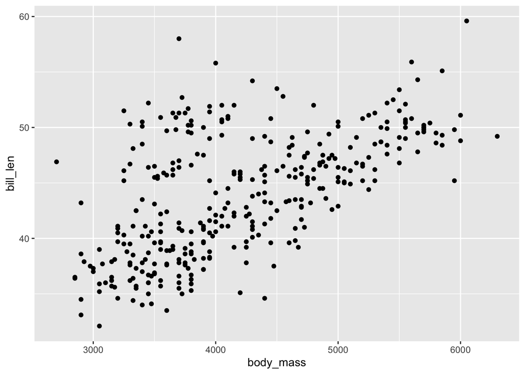

```r
library(ggplot2)
ggplot(penguins, aes(x = body_mass,
                     y = bill_len)) +
  geom_point()
```

Because the grammar of graphics is layered, we can specify more than one geom in the same plot. For instance,

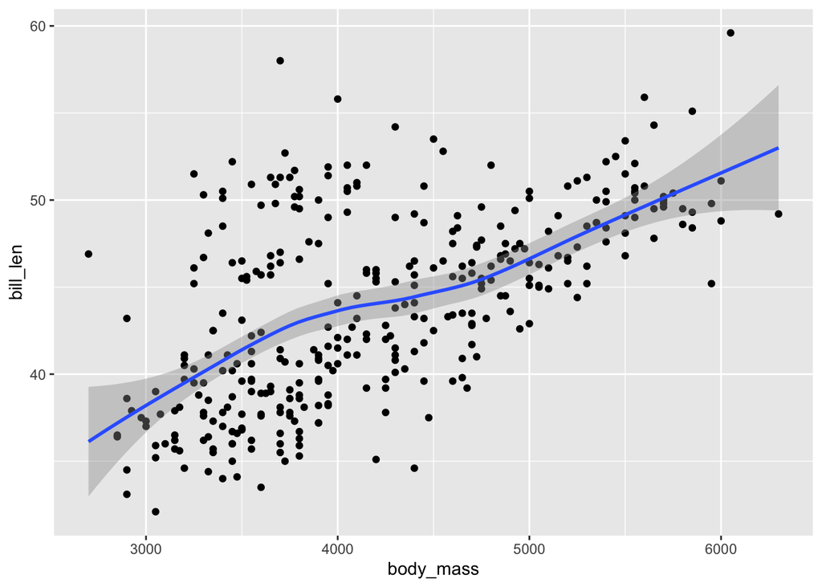

```r
ggplot(penguins, aes(x = body_mass,
                     y = bill_len)) +
  geom_point() +
  geom_smooth()
```

We control the appearance of the individual geoms by adding arguments inside their respective calls.

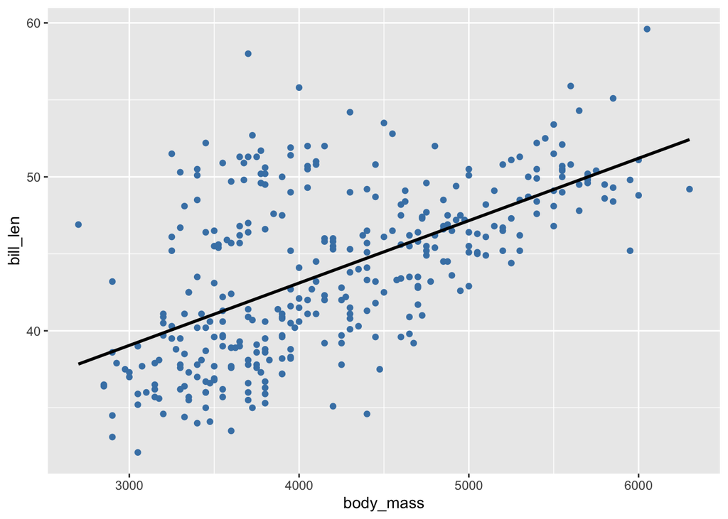

```r
ggplot(penguins, aes(x = body_mass,
                     y = bill_len)) +
  geom_point(color = "steelblue") +
  geom_smooth(method = "lm",
              se = FALSE,
              color = "black")
```

Other useful arguments include shape, size, and alpha (opacity).

The appearance of the overall plot is controlled by adding additional functions to the `ggplot` call.

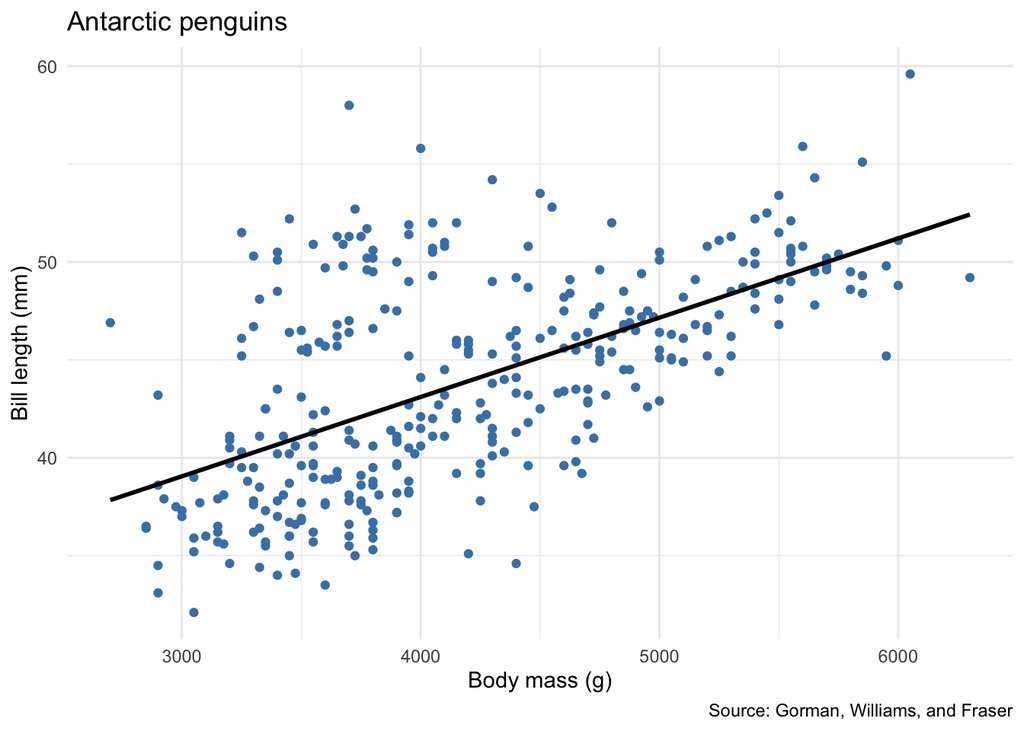

```r
ggplot(penguins, aes(x = body_mass,
                     y = bill_len)) +
  geom_point(color = "steelblue") +
  geom_smooth(method = "lm",
              se = FALSE,
              color = "black") +
  labs(x = "Body mass (g)",
       y = "Bill length (mm)",
       title = "Antarctic penguins",
       caption = "Source: Gorman, Williams, and Fraser") +
  theme_minimal()
```

So far, color has been an absolute characteristic of the geoms. If we want it to be controlled by a categorical variable like `species`, it becomes an aesthetic.

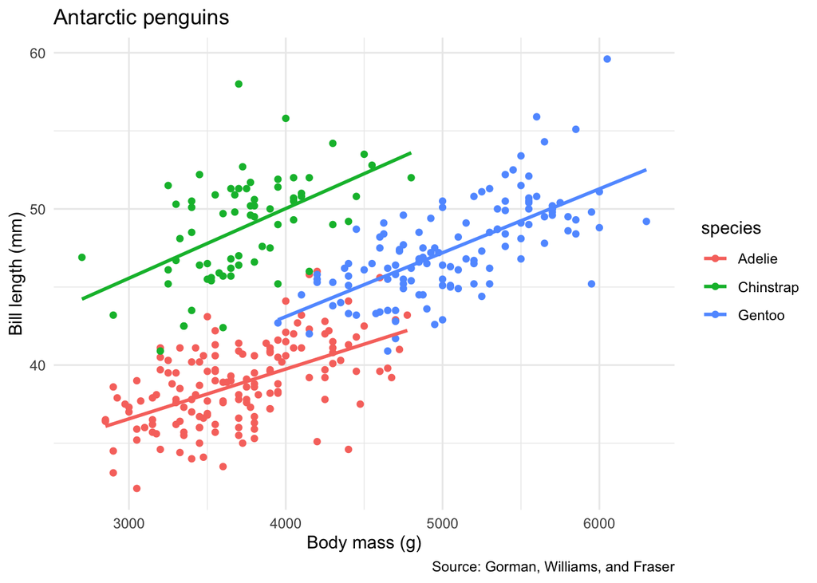

```r
ggplot(penguins, aes(x = body_mass,
                     y = bill_len,
                     color = species)) +
  geom_point() +
  geom_smooth(method = "lm",
              se = FALSE) +
  labs(x = "Body mass (g)",
       y = "Bill length (mm)",
       title = "Antarctic penguins",
       caption = "Source: Gorman, Williams, and Fraser") +
  theme_minimal()
```

The default color palette isn’t very accessible. Let’s swap it out.

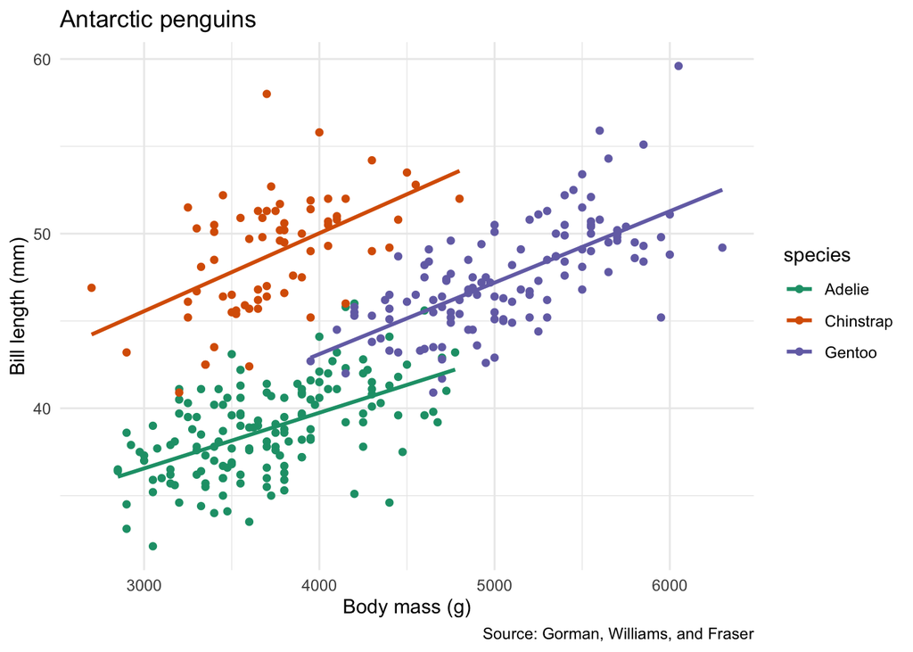

```r
ggplot(penguins, aes(x = body_mass,
                     y = bill_len,
                     color = species)) +
  geom_point() +
  geom_smooth(method = "lm",
              se = FALSE) +
  labs(x = "Body mass (g)",
       y = "Bill length (mm)",
       title = "Antarctic penguins",
       caption = "Source: Gorman, Williams, and Fraser") +
  theme_minimal() +
  scale_color_brewer(palette = "Dark2")
```

The scatterplot is the go-to when visualizing 2 quantitative variables, but there are many other possibilities, including `geom_line`. The cheat sheet in the help menu shows many more.

For a single quantitative variable, the usual choice is the histogram. For a single categorical variable, it’s the bar chart.

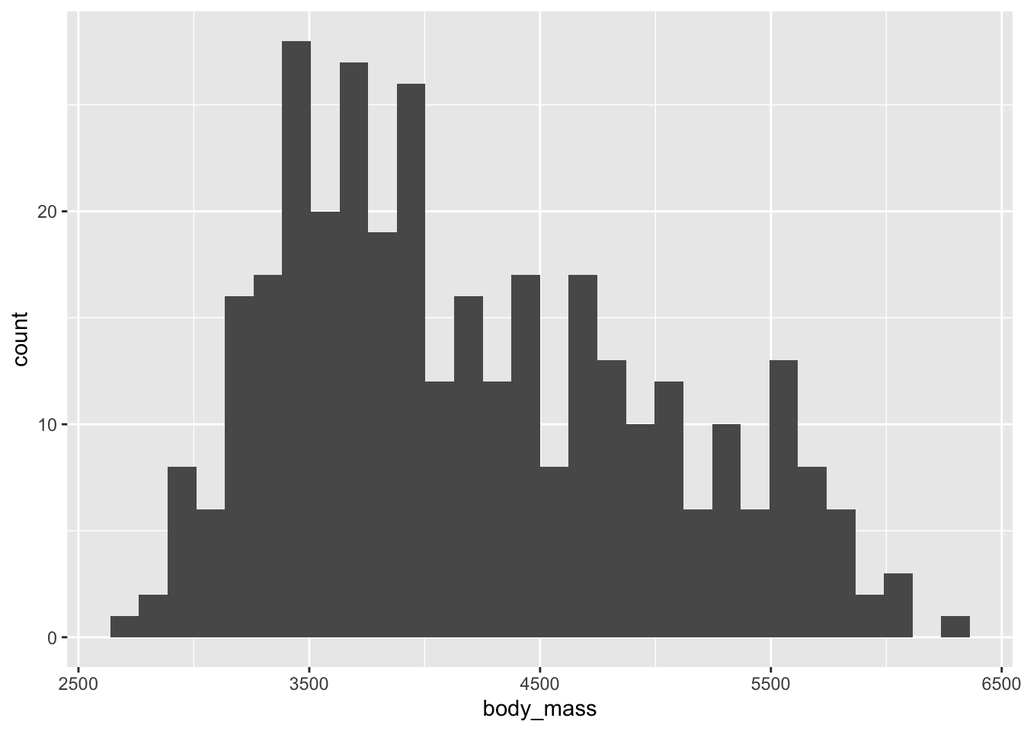

```r
ggplot(penguins, aes(x = body_mass)) +
  geom_histogram()
```

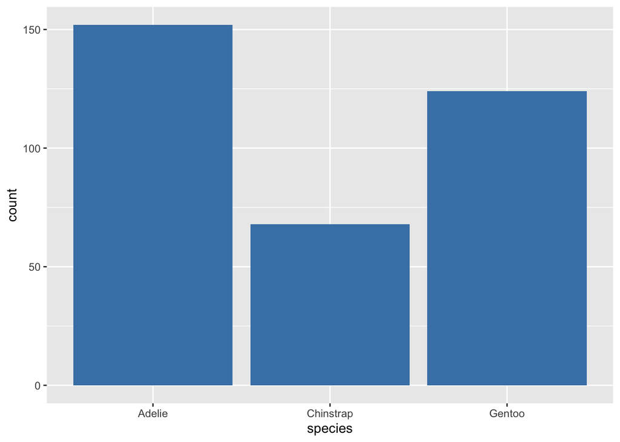

```r
ggplot(penguins, aes(x = species)) +
  geom_bar(fill = "steelblue")
```

Finally, the boxplot is a good way to display one categorical and one quantitative variable.

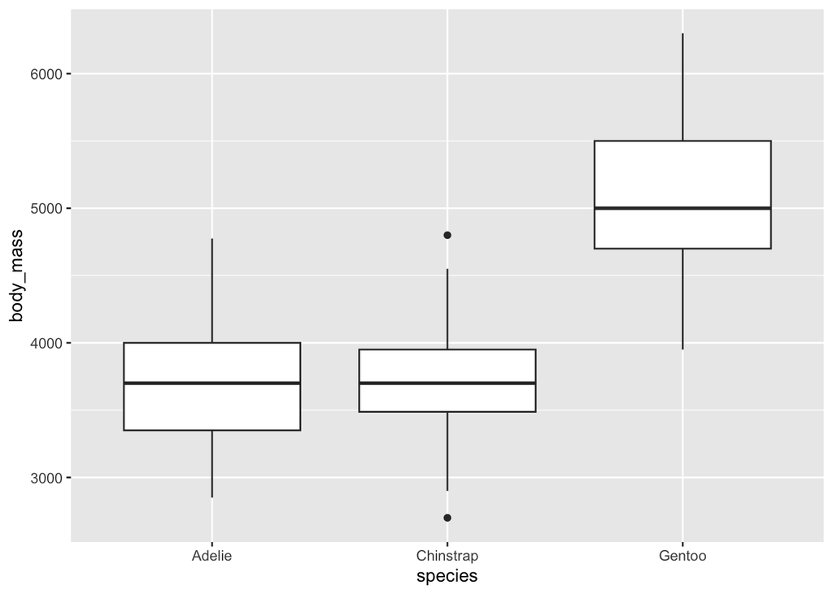

```r
ggplot(penguins, aes(x = species,
                     y = body_mass)) +
  geom_boxplot()
```

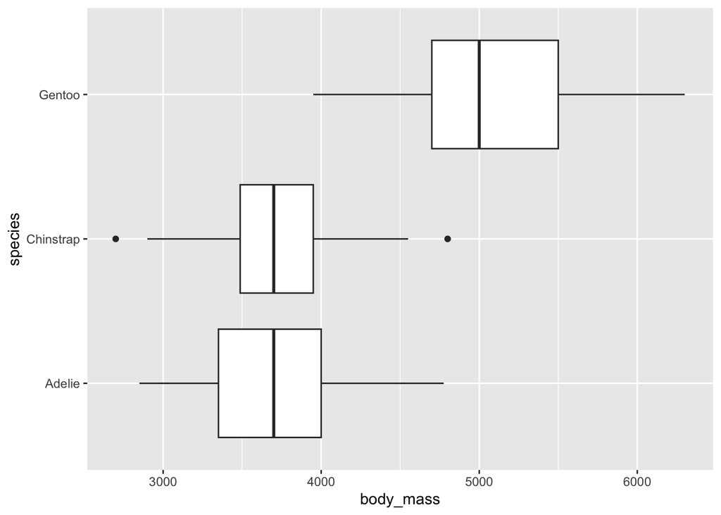

```r
ggplot(penguins, aes(y = species,
                     x = body_mass)) +
  geom_boxplot()
```